# Single-Parameter Models

```r
library(LearnBayes)
```

### 3.1

Use of `R` in summrarizing the posterior distribution.

### 3.2 Normal distribution with known mean but unknown variance

**Problem:** estimate an unknown variace. - $d_i$: difefrence of score = winning score - losing score

Suppose $d$ follows a normal distribution with mean 0 and var $\sigma^2$, then the likelihood is:
$$L(\sigma^2) \propto \frac{1}{\sigma^{n/2}}\exp\left\{ -\sum_{i=1}^n\frac{d_i^2}{2\sigma^2} \right\}$$

Also suppose the *noninformative* prior density $p(\sigma^2) \propto 1/\sigma^2$ is assigned to the var. This means that the log of var has a uniform distribution. Here is the proof.
$$\text{Let }X = \sigma^2, Y = \log \sigma^2,\\
\text{then we have } Y = \log X \Longleftrightarrow X = e^Y.\\
\text{Also recall that we have }p(X) = p(\sigma^2) \propto \frac{1}{\sigma^2} = \frac{1}{X}.\\
\text{Thus } p(Y) = p(\log(\sigma^2)) = |\frac{\partial X}{\partial Y}|p(X) \\
\propto |\frac{\partial e^Y}{\partial Y}|\cdot 1/X = e^Y\cdot 1/e^Y = 1. \\
\text{Thus }p(\log(\sigma^2)) \propto 1$$
**Numerical example** Theoretically, $p(\log(\sigma^2))$ have uniform diststribution but it cannot be expressed in the real case since we cannot take the nearest value of 0 and $\infty$, especially very small positive value. (improper prior)

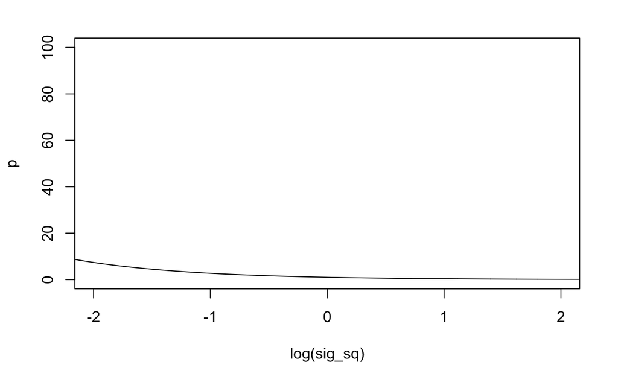

```r
sig_sq = seq(10^-2,10^2,.01)  # assume that we limit the lower/upper bound as 10^-2 and 10^2
p = 1/sig_sq  # probabilty over the variance
plot(log(sig_sq),p,type="l",xlim=c(-2,2))  # plot with the log(\sigma^2) => (looks) uniform
```

```r
#curve()
```

Then the posterior of $\sigma^2$ is given by:
$$g(\sigma^2|\text{data}) \propto (\sigma^2)^{-n/2-1}\exp\{-\frac{v}{2\sigma^2}\}$$
where $v = \sum_{i=1}^n d_i^2$. Defining the *precision parameter* $P = 1/\sigma^2$, then $P \sim U/v$ where $U$ has a chi-squared distribution with $n$ degree of freedom.

$$\frac{\sum_{i=1}^n d_i^2}{\sigma^2} = \sum_{i=1}^n (\frac{d_i - 0}{\sigma})^2 = \sum_{i=1}^n Z_i^2 \sim \chi^2(n) \\
\Longleftrightarrow \frac{1}{\sigma^2} \sim \frac{U}{v}$$

Use the data of `footballscores` from `LearnBayes`.

```r
data("footballscores")
attach(footballscores)  # serch the path -> read dataframe
d = favorite - underdog - spread  # define the "difference"
n = length(d) # number of data
v = sum(d^2)  # sum of squares
```

First generate 1000 samples from chi-squared($n$) distribution then convert $P$ by $\sigma = \sqrt{1/P}$. `hist` command makes the histogram.

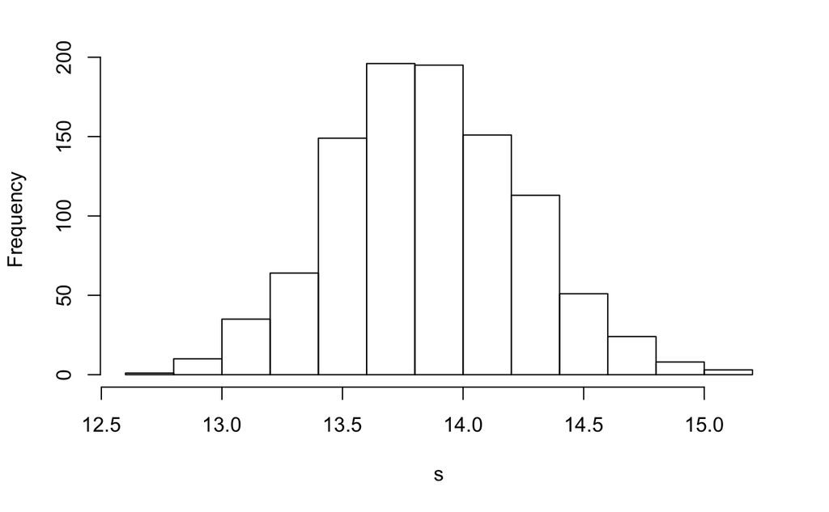

```r
P = rchisq(1000, n)/v
s = sqrt(1/P)
hist(s, main="")
```

`quantile` command : to extract a quantile. Here we see at 2.5%, 50%, and 97.5%.

```r
quantile(s, probs = c(.025,.5,.975))
```

```
    2.5%      50%    97.5%
13.11565 13.84772 14.62972
```

We see that the 95% probability interval for $\sigma$ is (13.1, 14.6) and the median is 13.85.

### 3.3 Esitmating a Heart Transplant Mortality Rate

**Problem:** rate of success of heart transplant surgery.

- $n$: number of surgeries
- $y$: num of death in 30 days, which follows *Poisson distribution* (https://en.wikipedia.org/wiki/Poisson_distribution) with mean $e\lambda$.
- knowing probability of death for each individual patient.
- $e$: size of the exposure.

We want to esitmate $\lambda$, the mortatily rate per unit exposure! Statndard approach is by the MLE: $\hat \lambda = y/e$ but it can be poor. So we use a Bayesian approach (since we assume that the number of death $y$ is close to zero).

The prior by gamma($\alpha,\beta$):
$$p(\lambda) \propto \lambda^{\alpha-1} \exp(- \beta \lambda), \lambda > 0$$

For the prior, assume that we have the data from other 10 hospitals which are: - $z_j$: num of death - $o_j$: num of exposure Note that $z_j$ follows Poisson with mean $\lambda o_j$.

If we assign the standard noninformative prior, $\alpha=\beta=0$, $p(\lambda) \propto \lambda^{-1}$, then the updated version is
$$p(\lambda) \propto \lambda^{\sum_{j=1}^{10}z_j-1} \exp(- (\sum_{j=1}^{10}o_j) \lambda)$$
We suppose
$$\sum_{j=1}^{10}z_j = 16, \sum_{j=1}^{10}o_j = 15174$$
so assign gamma(16,15174) as prior.

Then, suppose we observe that $y_o$ death for a given hospital with exposure $e$. Then the posterior will be gamma($\alpha+y_o,\beta+e$). Also the (prior) predictive distribution of $y$, $f(y)$ can be expressed as (assuming that the exposure is $e$)
$$f(y) = \frac{f(y|\lambda)g(\lambda)}{g(\lambda|y)}$$

where $f(y|\lambda)$ is the Possion($e\lambda$) sampling density, $g(\lambda)/ g(\lambda|y)$ are the prior/posterior.

One can check whether this model is reasonable or not by comparing the predictive distribution $f(y)$ and the real observation $y_o$.

**Case 1** Hospital A observes 1 death with 66 exposure. The standard estimate of A’s mortality rate is 1/66. But with our method, noting that $E[\lambda] = \alpha/\beta$,

```r
alpha = 16; beta = 15174
yobs = 1; exposure = 66
y = 0:10 # possible death observation
lam = alpha/beta  # prior estimation of lambda = expected value from gamma distribution
# compute the prior predictive distribution for each y
fy = dpois(y, exposure*lam) * dgamma(lam, shape = alpha, rate = beta)/ dgamma(lam, shape = alpha + y, rate = beta + exposure)
cbind(y,round(fy,3))
```

```
       y
 [1,]  0 0.933
 [2,]  1 0.065
 [3,]  2 0.002
 [4,]  3 0.000
 [5,]  4 0.000
 [6,]  5 0.000
 [7,]  6 0.000
 [8,]  7 0.000
 [9,]  8 0.000
[10,]  9 0.000
[11,] 10 0.000
```

We observe that $y$ highly occures 0 or 1 -> hence it seems reasonable modeling!! Then take 1000 samples of $\lambda_A$ with the posterior gamma($\alpha+1,\beta+66$).

```r
lambdaA = rgamma(1000, shape=alpha+yobs, rate = beta+exposure)
```

**Case 2** Hospital B observes 4 deaths with 1767 exposure. The standard estimate of B’s mortality rate is 4/1767. We do the same as before,

```r
yobsB = 4; exposureB = 1767
y = 0:10 # possible death observation
lam = alpha/beta  # prior estimation of lambda = expected value from gamma distribution
# compute the prior predictive distribution for each y
fyB = dpois(y, exposureB*lam) * dgamma(lam, shape = alpha, rate = beta)/ dgamma(lam, shape = alpha + y, rate = beta + exposureB)
cbind(y,round(fyB,3))
```

```
       y
 [1,]  0 0.172
 [2,]  1 0.286
 [3,]  2 0.254
 [4,]  3 0.159
 [5,]  4 0.079
 [6,]  5 0.033
 [7,]  6 0.012
 [8,]  7 0.004
 [9,]  8 0.001
[10,]  9 0.000
[11,] 10 0.000
```

We see that $y_o=4$ is not such a huge extreame case, so it is also reasonable. Again, we take the sample of $\lambda$ from the posterior, gamma($\alpha+4,\beta+1767$).

```r
lambdaB = rgamma(1000, shape=alpha+yobsB, rate = beta+exposureB)
```

Then we see the prior/posterior relation.

```r
par(mfrow = c(2,1)) # subplot (2 by 1)
# for hospital A
plot(density(lambdaA), main = "HOSPITAL A", xlab = "lambdaA", lwd = 3) # posterior for A
curve(dgamma(x,shape = alpha, rate = beta), add = TRUE)  # prior
```

```r
legend("topright",legend = c("prior","posterior"), lwd = c(1,3))
# for hospital B
plot(density(lambdaB), main = "HOSPITAL B", xlab = "lambdaB", lwd = 3) # posterior for B
```

[figure not shown]

```r
curve(dgamma(x,shape = alpha, rate = beta), add = TRUE)  # prior
legend("topright",legend = c("prior","posterior"), lwd = c(1,3))
```

We observe that the posterior of B changes more than A. (The prior has less influence due to the large number of surgeries.)

### 3.4 An Illustration of Bayesian Robustness

If we have some idea for prior of a paramter $\theta$, such as “median of $\theta$ is 30” or “80th percentile is 50”, then one can design such prior in many ways. However, after observing data and generating a posterior, one want the posteriro to be *robust* to the choice of prior, i.e. the posterior should be insensitive to the choice of priors which match the user’s beliefs.

To illustrate the idea, suppose we are interested in finding the IQ for Joe. We are believing that: - Joe has average interigence - Joe’s IQ falls in [80,120] w.p. 90%

#### Normal Distribution

If we use the Normal distribution as the prior, we can say that:

- 50th percentile is $\theta = 100$
- 95th percentile is $\theta = 120$ (from symmetry of Normal dist)

```r
quantile1 = list(p=.5,x=100); quantile2 = list(p=.95,x=120)
normal.select(quantile1,quantile2)
```

```
$mu
[1] 100

$sigma
[1] 12.15914
```

Hence, the prior is $\mathcal{N}(\mu_0,\tau_0)$ with $\mu_0 = 100, \tau_0 = 12.16$. Note the precision is $P_0 = 1/\tau_0^2 = 1/12.16^2$.

Joe did 4 tests, $y_1,...,y_4$. Assume that each individual test’s score $y$ follows $\mathcal{N}(\theta,\sigma)$ with *known* $\sigma=15$, thus the precision is $P= 1/15^2$ Then, the posterior hyperparameters of $\theta$ (precision $P_1$ and mean $\mu_1$) are: (https://en.wikipedia.org/wiki/Conjugate_prior)
$$P_1 = 4 \times P + P_0 = 4/\sigma^2 + 1/\tau_0^2\\
\text{Hence the std-dev is }\tau_1 = 1/\sqrt{P_1} = \frac{1}{\sqrt{4/\sigma^2 + 1/\tau_0^2}}$$
for the mean is
$$\mu_1 = \frac{P_0\mu_0 + P \times \sum_{i=1}^4y_i}{P_0 + 4P} = \frac{(1/\tau_0^2)\mu_0 + (1/\sigma^2)\times\sum_{i=1}^4y_i}{1/\tau_0^2 + 4/\sigma^2}\\
= \frac{(1/\tau_0^2)\mu_0 + (4/\sigma^2)\bar y}{1/\tau_0^2 + 4/\sigma^2}$$
where $\bar y = \sum_{i=1}^4y_i / 4$, the sample mean. Suppose we observe $\bar y = 110, 125, 140$ then, estimate the posterior distirbution of $\theta$

```r
mu0 = 100; tau0 = 12.16  # hyperparams for prior
sigma = 15 # suppose we know the variance of each test
n = 4 # num of tests
ybar = c(110, 125, 140)
tau1 = 1/sqrt(4/sigma^2 + 1/tau0^2)
mu1 = (1/tau0^2*mu0+ 4/sigma^2*ybar)*tau1^2
summ1 = cbind(ybar, mu1, tau1)
summ1
```

```
     ybar      mu1     tau1
[1,]  110 107.2442 6.383469
[2,]  125 118.1105 6.383469
[3,]  140 128.9768 6.383469
```

#### t-distribution

Now, let’s use a different prior. Any symmetric distribution are applicable hence here we use *t distribtuion* (https://en.wikipedia.org/wiki/Student%27s_t-distribution) with location $\mu$, scale $\tau$, and 2 degrees of freedom. i.e. $T = \frac{\theta-\mu}{\tau}$ follows a t-distribution.

Then, 95th percentile should be 120,
$$P(\theta \leq 120)= P({\tau}T\leq 20) = P(T\leq \frac{20}{\tau})=0.95$$
where $T$ is a standard t variable with 2 degrees of freedom. It follows:
$$\tau = 20/t_2(.95)$$
$t_v(p)$: $p$th quantile of a t random variable with $v$ degrees of freedom.

```r
tscale = 20/qt(.95,2)
tscale
```

```
[1] 6.849349
```

We see the two priors in the following.

```r
#par(mfrow=c(2,1))
curve(1/tscale*dt((x-mu0)/tscale,2),from = 60, to = 140, xlab = "theta", ylab = "Prior Density")  # pdf needs to be scaled by 1/simga
curve(dnorm(x,mean = mu0,sd=tau0), add = TRUE, lwd = 3)
```

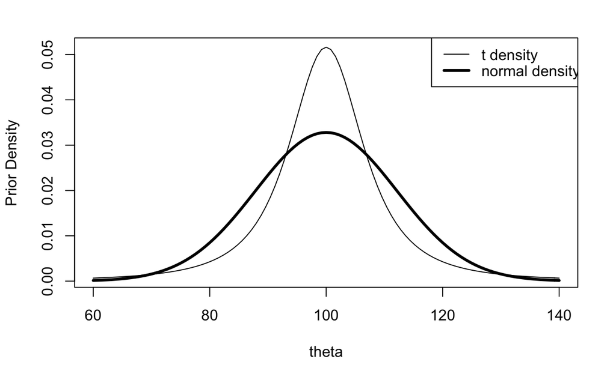

```r
legend("topright",legend = c("t density", "normal density"), lwd = c(1,3))
```

The posterior is given by
$$g(\theta|data) \propto \phi(\bar y|\theta, \sigma/\sqrt{n})g_T(\theta| v,\mu,\tau)$$
where

- $\phi(\bar y|\theta, \sigma)$: a normal density with mean $\mu$ and std-dev $\sigma$
- $g_T(\theta| v,\mu,\tau)$: a t density with median $\mu$, scale param $\tau$ and degrees of freedom $v$.

Since this posterior does not have a convenient functional form, we compute by a direct way: *prior $\times$ likelihood*.

```r
norm.t.compute = function(ybar){  # compute posterior expectation and std for each val of ybar
  theta = seq(60,180, length=500)  # grid for theta
  like = dnorm(theta, mean = ybar, sd = sigma/sqrt(n))  # likelihood function of ybar
  prior = dt((theta-mu0)/tscale,2)  # prior (ignore tscale^-1)
  post = prior*like
  post = post/sum(post)  # scale to be probability
  m = sum(theta*post)  # expected value of theta with posterior
  s = sqrt(sum(theta^2*post)-m^2)  # standard dev of theta with posterior
  c(ybar,m,s)
}
summ2 = t(sapply(c(110,125,140),norm.t.compute))
dimnames(summ2)[[2]] = c("ybar","mu1 t","tau1 t")
summ2
```

```
     ybar    mu1 t   tau1 t
[1,]  110 105.2921 5.841676
[2,]  125 118.0841 7.885174
[3,]  140 135.4134 7.973498
```

```r
cbind(summ1,summ2)
```

```
     ybar      mu1     tau1 ybar    mu1 t   tau1 t
[1,]  110 107.2442 6.383469  110 105.2921 5.841676
[2,]  125 118.1105 6.383469  125 118.0841 7.885174
[3,]  140 128.9768 6.383469  140 135.4134 7.973498
```

We observe:

- when $\bar y = 110$, post mean and std are similar
- but $\bar y$ is large, i.e. different from the belief of prior, then t dist reflect the data result.

**Extreme case: $\bar y = 140$**

```r
theta = seq(60,180, length=500)
normpost = dnorm(theta, mean=mu1[3], sd=tau1)
normpost = normpost/sum(normpost)
plot(theta,normpost, type = "l", lwd=3,ylab = "Posterior Density")
like = dnorm(theta,mean = 140, sd = sigma/sqrt(n))
prior = dt((theta-mu0)/tscale,2)
tpost = like*prior
tpost = tpost/sum(tpost)
lines(theta,tpost)
```

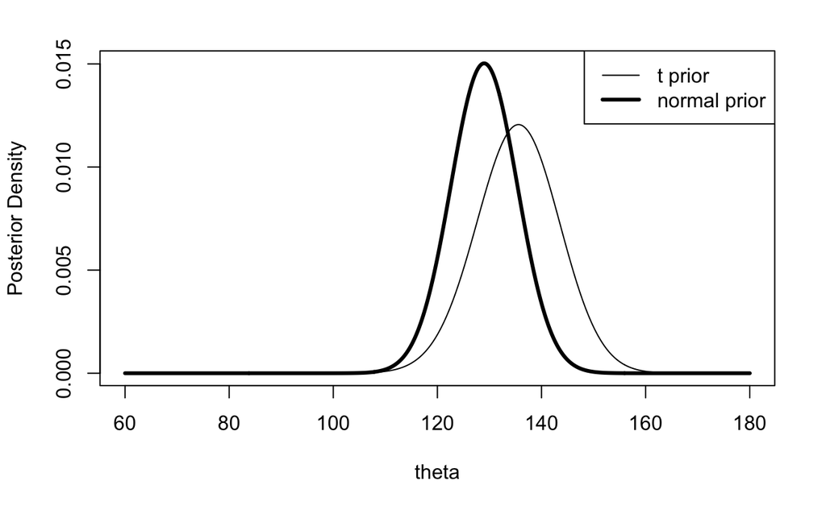

```r
legend("topright", legend = c("t prior", "normal prior"), lwd = c(1,3))
```

**Summary**

- If the observation is close to the prior belief, the inference about mean is robust to the choice of prior
- However, if the observation is different, the inference is not robust.

### 3.5 Mixtures of Conjugate Priors

Extend the idea of conjugate priors by using discrete mixtures.

**Problem**: learn about the prob of that a biased coin lands heads.

Let $p$ be the prob of the coin lands heads, and our belief on that is either $p$ is close to 0.3 or 0.7. This prior can be expressed as follows:
$$g(p) = \gamma g_1(p) + (1-\gamma)g_2(p)$$
where $g_1$ is beta(6,14), and $g_2$ is beta(14,6), and the mixing prob is $\gamma=0.5$.

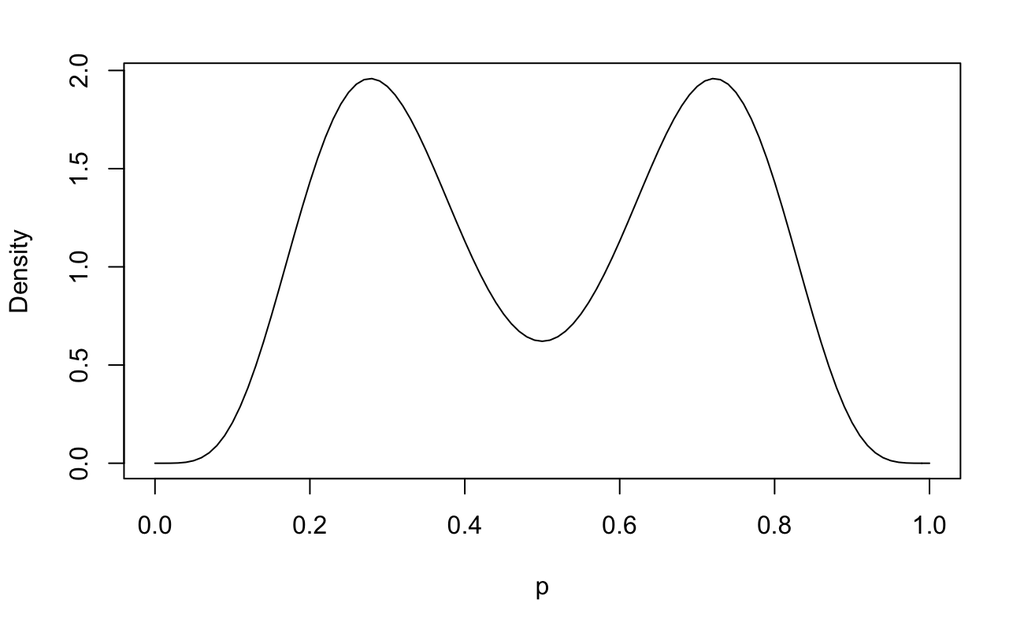

```r
curve(0.5 * dbeta(x,6,14) + 0.5 * dbeta(x,14,6), from = 0, to = 1, xlab = "p", ylab = "Density")
```

Suppose we filp the coin $n$ times, and observe $s$ heads and $f=n-s$ tails.The posterior can be written as:
$$g(p|\text{data}) \propto \gamma(\text{data}) g_1(p|\text{data}) + (1-\gamma(\text{data}))g_2(p|\text{data})$$
where $g_1$ is beta($6+s,14+f$), $g_2$ is beta($14+s,6+f$) and $\gamma(\text{data})$ is
$$\gamma(\text{data}) = \frac{\gamma f_1(s,f)}{\gamma f_1(s,f) + (1-\gamma)f_2(s,f)}$$
where $f_j(s,f)$ is the prior predictive probability of $s$ heads in $n$ flip when the prior is $g_j$ I don’t know where this comes from and how to compute the prior predictive probabaility.

**My solution**
$$f_i(s,f) = \frac{f_i(s,f|p) g_i(p)}{g(p|s,f)}$$
where

- $f_i(s,f|p)$ binomial distribution of getting heads $s$ times with the probality $(a_i+s)/(a_i+b_i+s+f)$ i.e. prob after observing the data where $a_i,b_i$ is the params of the beta prior.
- $g_i(p)$: prior beta($a_i,b_i$) density of getting $p = (a_i+s)/(a_i+b_i+s+f)$
- $g_i(p|s,f)$: posterior beta($a_i+s,b_i+f$) density of getting $p = (a_i+s)/(a_i+b_i+s+f)$

```r
s = 7; f = 3
f1 = dbinom(s, s+f, (6+s)/(20+s+f))*dbeta((6+s)/(20+s+f), 6, 14)/dbeta((6+s)/(20+s+f), 6+s, 14+f)
f2 = dbinom(s, s+f, (14+s)/(20+s+f))*dbeta((14+s)/(20+s+f), 14, 6)/dbeta((14+s)/(20+s+f), 14+s, 6+f)
f1/(f1+f2); f2/(f1+f2)
```

```
[1] 0.09269663
[1] 0.9073034
```

But my intuition is as follows. The sampling density and prior (the numerator of the above equation) should be besed only on *prior beliefs* not the observation of data.

```r
f1a = dbinom(s, s+f, (6)/(20))*dbeta((6)/(20), 6, 14)/dbeta((6+s)/(20+s+f), 6+s, 14+f)
f2a = dbinom(s, s+f, (14)/(20))*dbeta((14)/(20), 14, 6)/dbeta((14+s)/(20+s+f), 14+s, 6+f)
f1a/(f1a+f2a); f2a/(f1a+f2a)
```

```
[1] 0.0351314
[1] 0.9648686
```

```r
probs = c(.5, .5)  # initial gamma
beta.par1 = c(6,14)  # 1st prior
beta.par2 = c(14,6)  # 2nd prior
betapar = rbind(beta.par1,beta.par2)
data=c(7,3)  # observation, 7 heads 3 tails
post = binomial.beta.mix(probs,betapar,data)  # compute posteriro with mix beta priors
post
```

[output not shown]

```r
curve(post$probs[1]*dbeta(x,13,17)+post$probs[2]*dbeta(x,21,9),from = 0, to = 1, lwd = 3, xlab = "p", ylab = "Density")
curve(.5*dbeta(x,6,14)+.5*dbeta(x,14,6), from = 0, to=1, add=TRUE)
legend("topleft", legend = c("Prior","Posterior"), lwd = c(1,3))
```

[output not shown]

### 3.6 Bayesian Test of the Fairness of a Coin

**Problem**: assessing the fairness of a coin.

Suppose we observe $y$ heads from binomially distributed with parameters $n$ and $p$.

#### Frequentist Approach

Our interest is testing the hypothesis:
$$H: p=0.5$$
And the p-value can be obtained as:
$$\text{p-value} = \min\{P(Y\leq y|H),P(Y\geq y|H)\}$$
since we test the double tail event. If the p-val is *small* we reject the hypothesis because it implies that the hypothesis may not adequately explain the observation. In other words, the observation is far more rare event than under the hypothesis.

If we observe $y=5$ with $n=20$, then we can compute the p-val as

```r
2 * pbinom(5, 20, 0.5)
```

[output not shown]

since this value is smaller than 0.05, we reject the hypotheis and conclude that **the coin is not fair**.

#### Bayesian Approach

Here we see the problem from a Bayesian view point. Two models can be considered:

- the coin is fair ($p=0.5$)
- the coin is *not* fair ($p\neq0.5$)

Suppose we are indeferent in the two models so assing 1/2 for both. Thus the prior can be written as follows:
$$g(p) = 0.5 \cdot I(p=0.5) + 0.5 \cdot I(p \neq 0.5)\cdot g_1(p)$$
where $g_1(p)$ is a beta($a,a$) prior on $p$ (for the not fair belief), and $I$ is an indicator function, while if we believe the coin is fair, then $p=0.5$ (concentrated).

After observing data, we update the prior to the posterior:
$$g(p|y) = \lambda(y)I(p=0.5) + (1-\lambda(y))I(p \neq 0.5) g_1(p|y)$$
where $g_1(p|y)$ is beta($a+y,a+n-y$) and $\lambda(y)$ is the posterior prob of the model where the coin is fair,
$$\lambda(y) = \frac{.5P(Y=y|.5)}{.5P(Y=y|.5) + .5m_1(y)}$$
where $P(y|.5)$ is the binomial density for $y$ when $p=0.5$, and $m_1(y)$ is the prior predictive density for $y$ using the beta density, i.e.
$$m_1(y) = \frac{f(y|p)g_1(p)}{g_1(p|y)}$$
where $f(y|p)$ is the binomial density s.t. the prob of $y$ when $p$, $g_1(p)$ is the prior and $g_1(p|y)$ is the posterior assuming that the coin is not fair.

Here we set beta(10,10) for the prior of being a non fair coin

```r
n = 20; y = 5 # observation
a = 10  # param for prior for not being a fair coin
p = 0.5 # prior belief for being a fair coin
m1 = dbinom(y,n,p) * dbeta(p, a, a)/dbeta(p, a+y, a+n-y)  # prior predictive density for y
lambda = dbinom(y, n, p)/(dbinom(y, n, p) + m1)
lambda
```

[output not shown]

We get the posterior probability of the hypothesis of fairness (ie the coin is fare) is 28%, which is less evidence against fairness obtained by p-value test.

This value can be obtained by `pbetat` of `LearnBayes` package

```r
pbetat(p, 0.5, c(a,a),c(y,n-y))
```

[output not shown]

`bf` is the *Bayes facotr* in support of the null hypothesis, which will be discussed in Chapter 8.

Since the choice of $a=10$ is arbitrary, we want to see the sensitivity of the posterior calculation to the choice of the parameter.

```r
prob.fair = function(log.a){  # define a funciton to compute the post prob of fairness with input of log a
  a = exp(log.a)
  m2=dbinom(y, n, p)*dbeta(p,a,a)/dbeta(p,a+y,a+n-y)
  return(dbinom(y,n,p)/(dbinom(y,n,p)+m2))
}
```

Here we select the $\log(a)$ as the input of the function.

```r
n = 20; y = 5; p = 0.5
curve(prob.fair(x), from = -4, to = 5, xlab = "log a", ylab = "Prob(coin is fair)", lwd = 2)
```

[output not shown]

#### Another difference between Frequentist vs Bayesian

```r
n = 20; y = 5; p = 0.5; a = 10 # problem parameters
# compute P1
m2 = 0
for (k in 0:y){
  m2 = m2 + dbinom(k, n, p) * dbeta(p, a, a)/ dbeta(p, a+k, a+n-k)  # each m2
}
lambda = pbinom(y, n, p)/(pbinom(y, n, p) + m2)
lambda
```

[output not shown]

We see that the result 0.218 is smaller than the previous solution 0.280 which is based only on the num of heads is 5. Hence, this is reasonable since observing *5 heads or fewer* is stronger evidence against fairness than *5 heads*.